# Individual call analysis with LM/Ms

Thejasvi Beleyur

Last Updated : 2024-12-16 08:52:06.113891

This notebook will detail the use of bayesian linear models and mixed models to quantify the difference between single and multi-bat call properties. The final results are presented in the Parameter Summary. The estimated means and their compatibility intervals are in the Mean and Comp. Intervals section.

All intervals reported here are 95% highest posterior density compatibility intervals (Gelman and Greenland 2019; McElreath 2020). It is important to highlight here that the compatibility intervals (also known as credible intervals) are *not* to be confused with confidence intervals. While there may be a series of cases where the the confidence and credible intervals converge to the same numerical values - it is important to highlight that this is not the general case, and should not be treated as such (Nalborczyk et al. 2019).

```r
library(arm)
library(coda)
library(lme4)
library(stringi)
library(stringr)
set.seed(82319)
d <- read.csv('../individual_call_analysis/analysis/one_call_per_row_2020-12-17.csv')
# create a single/multi-bat categorical variable
d['multi_bat'] <- factor(d['num_bats']>1)
d['annot_id'] <- stri_sub(d$video_annot_id,8,-1)
d['annot_id'] <- str_replace_all(d$annot_id, '21502300','2123')
# sort the dataset by time first
time_ordering <- stri_order(d$annot_id,numeric=TRUE)
d_tordered <- d[time_ordering,]
# - is there an influence of the recording hour?
split.and.join <- function(x){
  splitx <- str_split(x,'_')
  jointx <- paste(splitx[[1]][1],'_',splitx[[1]][2],sep='')
  jointx}
d_tordered$rechour <- sapply(d_tordered$annot_id,split.and.join)

# also scale up some of the measurements into more meaningful units
# -- here we'll multiply by 10^3 to convert s to ms
d_tordered$tfm_duration <- d_tordered$tfm_duration*10^3
d_tordered$ifm_duration <- d_tordered$ifm_duration*10^3
d_tordered$cf_duration <- d_tordered$cf_duration*10^3
# convert Hz to kHz
d_tordered$tfm_terminal_frequency <- d_tordered$tfm_terminal_frequency * 10^-3
d_tordered$ifm_terminal_frequency <- d_tordered$ifm_terminal_frequency * 10^-3
d_tordered$cf_peak_frequency <- d_tordered$cf_peak_frequency*10^-3
# number of simulations to get from the posterior distribution
num_post <- 5000
# convenience function to generate 95% highest posterior density interval - for compatibility interval
get.hpd <- function(x,prange=0.95){HPDinterval(as.mcmc(x),prob=prange)}

# convenience function to make a vector with the MAP and compatibility intervals

get.map.coi <- function(x){c(mean(x), get.hpd(x))}
```

```r
# get annotations to remove just before splitting up the dataset into its component measurements
annots_to_remove <- read.csv('annotations_to_remove.csv')$annots_to_remove

annots.to.remove.present <- function(annotation.entry){
  # check if the row.entry has any of the substrings of the removable annotations
  remove.entry <- FALSE
  for (each in annots_to_remove){
    to.remove <- grepl(each, annotation.entry)
    if (isTRUE(to.remove))
    {
      remove.entry <- TRUE
    }
  }
  remove.entry
}

d_tordered['rows_to_remove'] <- lapply(d_tordered$audio_file, annots.to.remove.present)

# check to see if all the rows are valid after the filtering
all_valid_rows <- all(!d_tordered$rows_to_remove)
if (isTRUE(all_valid_rows)){
  # don't do anything
} else{
    stop("There are some rows to be removed - this hasn't been coded in right now.")}
```

## Duration parameters

### tFM duration

```r
tfmdurn.nona <- d_tordered[!is.na(d_tordered$tfm_duration),]
tfmdurn.formula <- formula(tfm_duration~multi_bat+(1|rechour))
tfmdurn.lmm <- lmer(tfmdurn.formula, data=tfmdurn.nona)
```

```
## boundary (singular) fit: see help('isSingular')
```

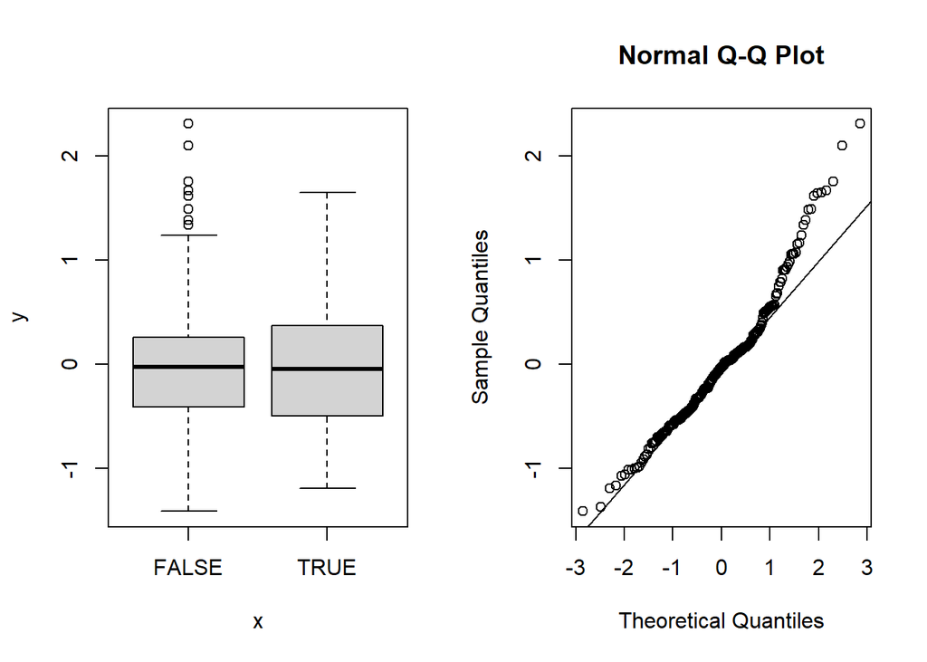

```r
# perform residual analysis
par(mfrow=c(1,2))
plot(tfmdurn.nona$multi_bat,resid(tfmdurn.lmm)) # the residuals seem to show no pattern between the explanatory variables
qqnorm(resid(tfmdurn.lmm));qqline(resid(tfmdurn.lmm))
```

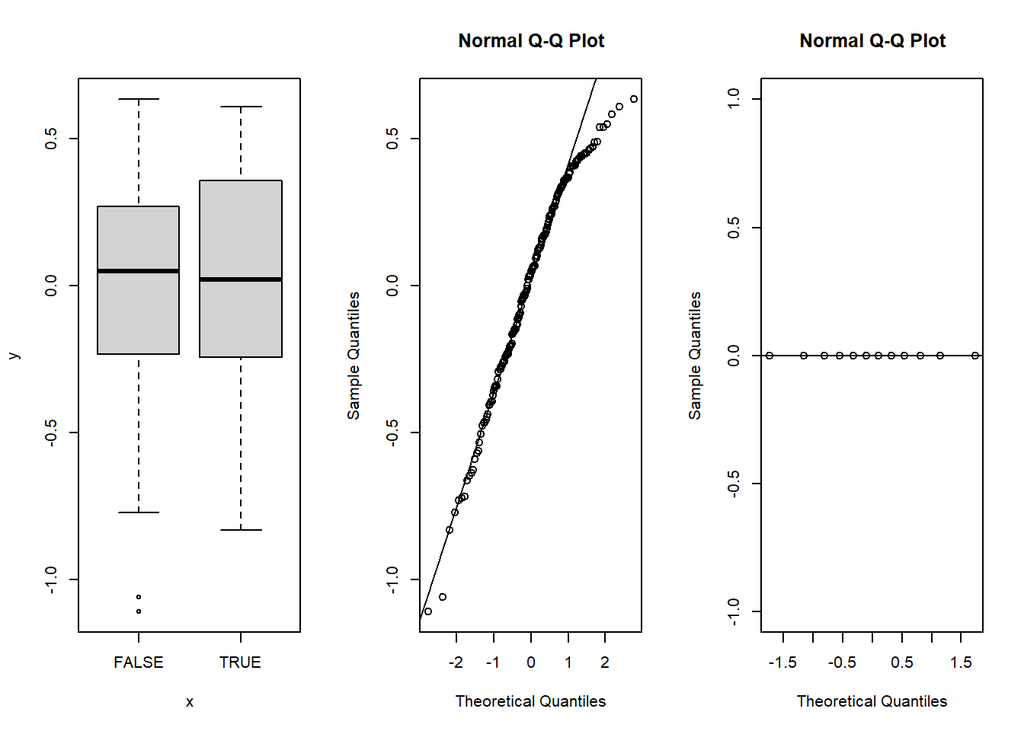

```r
# the top section of the qqplot shows some deviation - what if we get rid of the 'problematic' datapoints, and check if the estimates
# are affected
good_preds <- resid(tfmdurn.lmm)<=quantile(resid(tfmdurn.lmm),0.75)
tfmdurn.good <- tfmdurn.nona[good_preds,]
tfmdurn.lmm2 <- lmer(tfmdurn.formula, data=tfmdurn.good)

par(mfrow=c(1,3))
plot(tfmdurn.good$multi_bat,resid(tfmdurn.lmm2)) # the residuals seem to show no pattern between the explanatory variables
qqnorm(resid(tfmdurn.lmm2));qqline(resid(tfmdurn.lmm2))
qqnorm(ranef(tfmdurn.lmm)$rechour$`(Intercept)`);qqline(ranef(tfmdurn.lmm)$rechour$`(Intercept)`,main='random effects')
```

The fixed effects don’t seem to change too much with or without the ‘problematic’ data points leading to deviant residuals, and so I’d rather keep the full data - and present the posterior estimates of the coefficients.

```r
tfmdurn.sim <- sim(tfmdurn.lmm, n.sim=num_post)
tfmdurn.fixefs.hpd <- round(apply(fixef(tfmdurn.sim),2,get.hpd),2)
tfmdurn.rel.increase <- (fixef(tfmdurn.sim)[,1]+fixef(tfmdurn.sim)[,2])/fixef(tfmdurn.sim)[,1]
tfmdurn.ms.increase <- fixef(tfmdurn.sim)[,2]


# The relative change HPD interval and MAP (maximum a posteriori) estimates

# For relative changes
tfmdurn.rel.hpd <- round(get.hpd(tfmdurn.rel.increase),2)
tfmdurn.rel.map <- round(mean(tfmdurn.rel.increase), 2)
tfmdurn.rel.map.compint <- c(tfmdurn.rel.map, tfmdurn.rel.hpd)


# For unit time changes
tfmdurn.ms.change.hpd <- round(get.hpd(tfmdurn.ms.increase),2)
tfmdurn.ms.change.map <- round(mean(tfmdurn.ms.increase), 2)
tfmdurn.ms.change.map.compint <- c(tfmdurn.ms.change.map, tfmdurn.ms.change.hpd)

#Single and Multi bat mean MAP and Compatibility Intervals
tfmdurn.single <- fixef(tfmdurn.sim)[,1]
tfmdurn.multi <- tfmdurn.single + fixef(tfmdurn.sim)[,2]

# the columns are ordered so: single-mean-MAP, single-mean-lowerCoI, single-mean-upperCoI, multi-mean-lowerCoI, multi-mean-upperCoI
tfmdurn.mean.mapcoi <- c(get.map.coi(tfmdurn.single), get.map.coi(tfmdurn.multi))
```

Multi-bat tFMs are -0.01-0.39 ms longer than in single-bat calls. The overall relative increase in tFM duration is between 0.99, 1.23, indicating a scenario with no or slight increase in duration.

## iFM duration

```r
ifmdurn.nona <- d_tordered[!is.na(d_tordered$ifm_duration),]
ifmdurn.formula <- formula(ifm_duration~multi_bat+(1|rechour))
ifmdurn.lmm <- lmer(ifmdurn.formula, data=ifmdurn.nona)
```

```
## boundary (singular) fit: see help('isSingular')
```

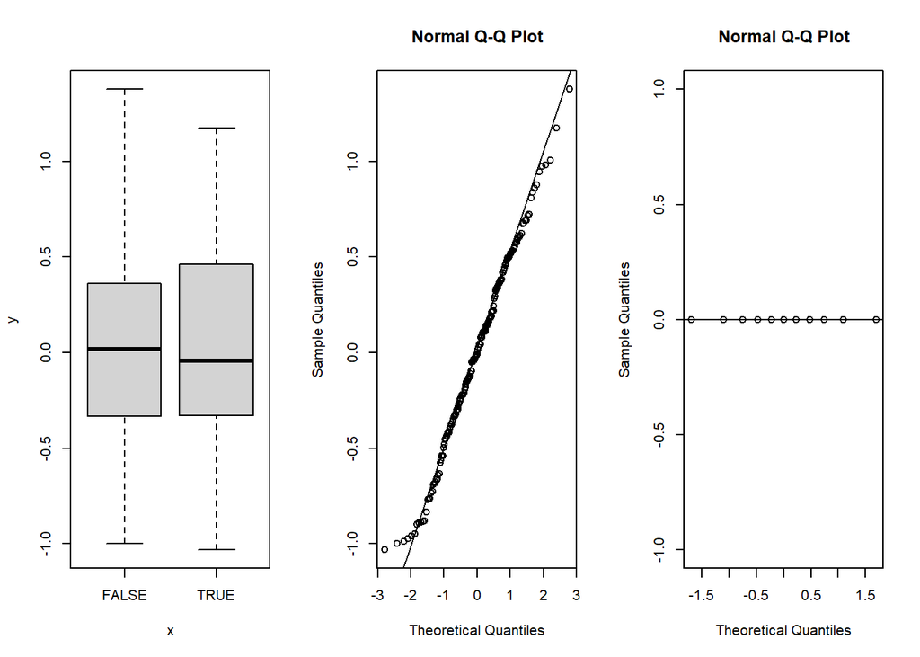

```r
# perform residual inspecition
par(mfrow=c(1,3))
plot(ifmdurn.nona$multi_bat,resid(ifmdurn.lmm)) # the residuals seem to show no pattern between the explanatory variables
qqnorm(resid(ifmdurn.lmm));qqline(resid(ifmdurn.lmm)) # the residuals fall very close to the qqline!
qqnorm(ranef(ifmdurn.lmm)$rechour$`(Intercept)`);qqline(ranef(ifmdurn.lmm)$rechour$`(Intercept)`,main='random effects')
```

The assumptions are met pretty well, and now we can generate the posterior distribution of the coefficients. There seem to be no random effects in place.

```r
ifmdurn.sim <- sim(ifmdurn.lmm, n.sim=num_post)

ifmdurn.fixefs.hpd <- round(apply(fixef(ifmdurn.sim),2,get.hpd),2)

# HPD interval and MAP estimate

# For relative change
ifmdurn.rel.increase <- (fixef(ifmdurn.sim)[,1]+fixef(ifmdurn.sim)[,2])/fixef(ifmdurn.sim)[,1]
ifmdurn.rel.hpd <- round(get.hpd(ifmdurn.rel.increase),2)
ifmdurn.rel.map <- round(mean(ifmdurn.rel.increase), 2)
ifmdurn.rel.map.compint <- c(ifmdurn.rel.map, ifmdurn.rel.hpd)


# For unit time change
ifmdurn.ms.increase <- fixef(ifmdurn.sim)[,2]
ifmdurn.ms.change.hpd <- round(get.hpd(ifmdurn.ms.increase), 2)
ifmdurn.ms.change.map <- round(mean(ifmdurn.ms.increase), 2)
ifmdurn.ms.change.map.compint <- c(ifmdurn.ms.change.map, ifmdurn.ms.change.hpd)


#Single and Multi bat mean MAP and Compatibility Intervals
ifmdurn.single <- fixef(ifmdurn.sim)[,1]
ifmdurn.multi <- ifmdurn.single + fixef(ifmdurn.sim)[,2]

# the columns are ordered so: single-mean-MAP, single-mean-lowerCoI, single-mean-upperCoI, multi-mean-lowerCoI, multi-mean-upperCoI
ifmdurn.mean.mapcoi <- c(get.map.coi(ifmdurn.single), get.map.coi(ifmdurn.multi))
```

The increase in iFM duration is between -0.16, 0.19 ms. The relative increase in iFM duration of multi-bat calls is also somewhat unclear between 0.88-1.15 times that of single bat calls.

## CF duration

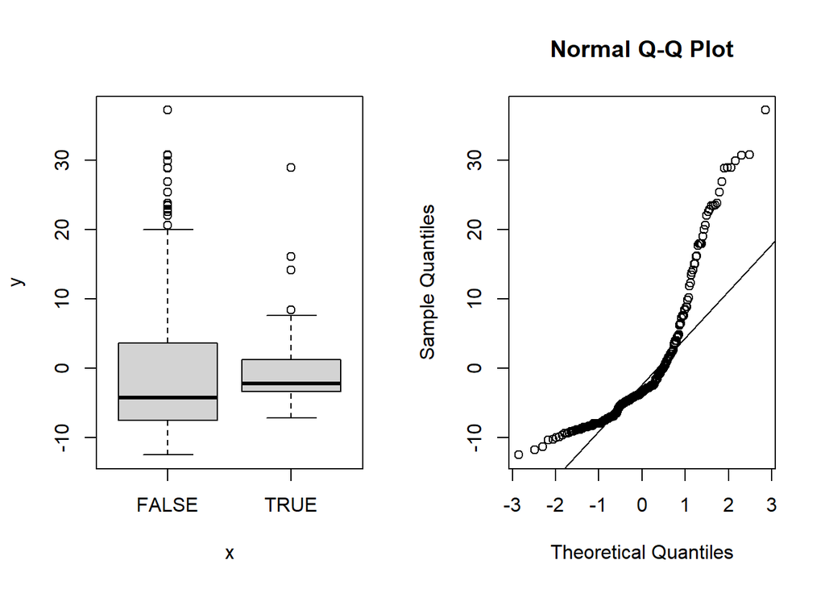

```r
cfdurn.nona <- d_tordered[!is.na(d_tordered$cf_duration),]
cfdurn.formula <- formula(cf_duration~multi_bat+(1|rechour))
cfdurn.lmm <- lmer(cfdurn.formula, data=cfdurn.nona)
# perform residual analysis
par(mfrow=c(1,2))
plot(cfdurn.nona$multi_bat,resid(cfdurn.lmm)) # the residuals seem to show no pattern between the explanatory variables
qqnorm(resid(cfdurn.lmm));qqline(resid(cfdurn.lmm))
```

The residuals are off, and I also think it may have to do with the distribution of very long and short CF durations in general. Let’s try to transform the CF duration and see if it improves the model fit.

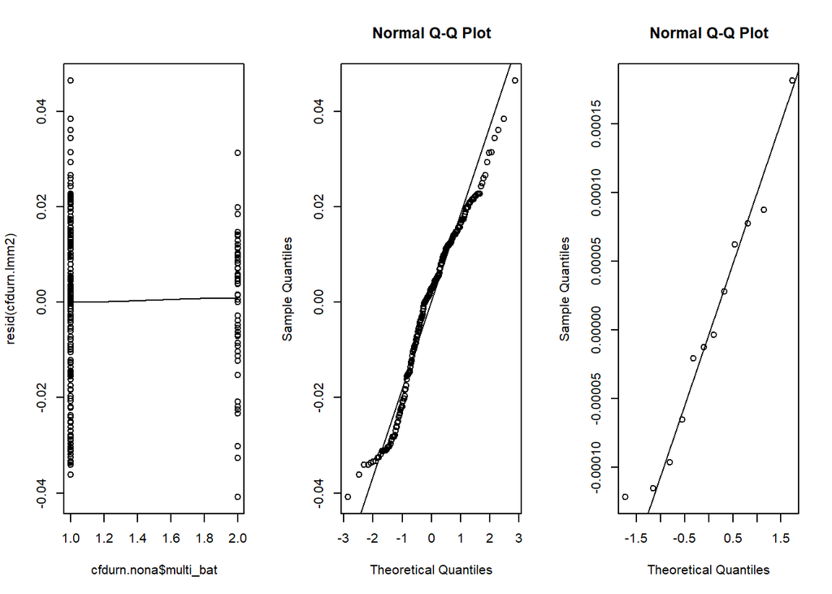

```r
# having tried the ln and sqrt transformations, the inverse seems to work best:
# https://www.itl.nist.gov/div898/handbook/pmd/section6/pmd633.htm
cfdurn.nona$invcfdurn <- 1/(cfdurn.nona$cf_duration)
cfdurn.lmm2 <- lmer(invcfdurn~multi_bat+(1|rechour), data=cfdurn.nona)

par(mfrow=c(1,3))
scatter.smooth(cfdurn.nona$multi_bat,resid(cfdurn.lmm2)) # the residuals seem to show no pattern between the explanatory variables
qqnorm(resid(cfdurn.lmm2));qqline(resid(cfdurn.lmm2))
qqnorm(ranef(cfdurn.lmm2)$rechour$`(Intercept)`);qqline(ranef(cfdurn.lmm2)$rechour$`(Intercept)`,main='random effects')
```

The residuals fit pretty well after an inverse transform, let us now proceed to generate the posterior distribution.

```r
cfdurn.sim <- sim(cfdurn.lmm2, n.sim=num_post)

cfdurn.fixefs.hpd <- round(apply(fixef(cfdurn.sim),2,get.hpd),2)
cfdurn.means.multi <- round((1/(fixef(cfdurn.sim)[,1]+fixef(cfdurn.sim)[,2])),2)
cfdurn.means.single <- round((1/fixef(cfdurn.sim)[,1]),2)
cfdurn.rel.increase <- cfdurn.means.multi/cfdurn.means.single
cfdurn.diff <- cfdurn.means.multi-cfdurn.means.single


# milliseconds change
cfdurn.diff.hpd <- round(get.hpd(cfdurn.diff), 2)
cfdurn.diff.map <- round(mean(cfdurn.diff), 2)
cfdurn.diff.map.compint <- c(cfdurn.diff.map, cfdurn.diff.hpd)

# relative change
cfdurn.rel.hpd <- round(get.hpd(cfdurn.rel.increase),2)
cfdurn.rel.map <- round(mean(cfdurn.rel.increase), 2)
cfdurn.rel.map.compint <- c(cfdurn.rel.map, cfdurn.rel.hpd)


cfdurn.mean.single <- round(mean(cfdurn.means.single),2)
cfdurn.single.hpd <- get.hpd(cfdurn.means.single)
cfdurn.mean.multi <- round(mean(cfdurn.means.multi),2)
cfdurn.multi.hpd <- get.hpd(cfdurn.means.multi)


#Single and Multi bat mean MAP and Compatibility Intervals
cfdurn.single <- 1/fixef(cfdurn.sim)[,1]
cfdurn.multi <- 1/(fixef(cfdurn.sim)[,1] + fixef(cfdurn.sim)[,2])

# the columns are ordered so: single-mean-MAP, single-mean-lowerCoI, single-mean-upperCoI, multi-mean-lowerCoI, multi-mean-upperCoI
cfdurn.mean.mapcoi <- c(get.map.coi(cfdurn.single), get.map.coi(cfdurn.multi))
```

The mean for CF duration for single bats is 18.93ms, and between 18.03, 19.91ms. The mean of multi-bat CF duration is 16.07ms, and between 14.88, 17.36ms. There is a relative decrease in CF duration in multi-bat calls of between 0.77, 0.93 in comparison to single-bat calls.

## tFM lower frequency

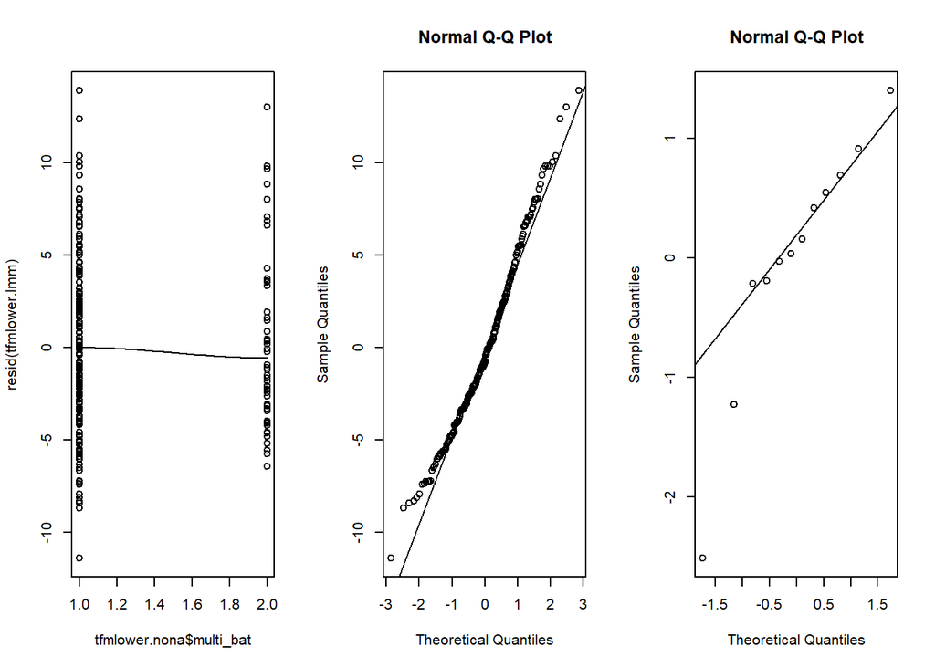

```r
tfmlower.nona <- d_tordered[!is.na(d_tordered$tfm_terminal_frequency),]
tfmlower.formula <- formula(tfm_terminal_frequency~multi_bat+(1|rechour))
tfmlower.lmm <- lmer(tfmlower.formula, data=tfmlower.nona)
# perform residual inspecition
par(mfrow=c(1,3))
scatter.smooth(tfmlower.nona$multi_bat,resid(tfmlower.lmm)) # the residuals seem to show no pattern between the explanatory variables
qqnorm(resid(tfmlower.lmm));qqline(resid(tfmlower.lmm))
qqnorm(ranef(tfmlower.lmm)$rechour$`(Intercept)`);qqline(ranef(tfmlower.lmm)$rechour$`(Intercept)`,main='random effects')
```

The model assumptions seem to be met. Let’s proceed and generate the posterior distribution of coefficients.

```r
tfmlower.sim <- sim(tfmlower.lmm, n.sim=num_post)

tfmlower.fixefs.hpd <- round(apply(fixef(tfmlower.sim),2,get.hpd),2)
tfmlower.fixefs.mean <- round(apply(fixef(tfmlower.sim),2,mean),2)

# relative
tfmlower.rel.increase <- (fixef(tfmlower.sim)[,1]+fixef(tfmlower.sim)[,2])/fixef(tfmlower.sim)[,1]
tfmlower.rel.hpd <- round(get.hpd(tfmlower.rel.increase),2)
tfmlower.rel.map <- round(mean(tfmlower.rel.increase),2)
tfmlower.rel.map.compint <- c(tfmlower.rel.map, tfmlower.rel.hpd)

# change in kHz
tfmlower.khz.change <- fixef(tfmlower.sim)[,2]
tfmlower.khz.hpd <- round(get.hpd(tfmlower.khz.change), 2)
tfmlower.khz.map <- round(mean(tfmlower.khz.change), 2)
tfmlower.khz.map.compint <- c(tfmlower.khz.map, tfmlower.khz.hpd)


#Single and Multi bat mean MAP and Compatibility Intervals
tfmlower.single <- fixef(tfmlower.sim)[,1]
tfmlower.multi <- tfmlower.single + fixef(tfmlower.sim)[,2]

# the columns are ordered so: single-mean-MAP, single-mean-lowerCoI, single-mean-upperCoI, multi-mean-lowerCoI, multi-mean-upperCoI
tfmlower.mean.mapcoi <- c(get.map.coi(tfmlower.single), get.map.coi(tfmlower.multi))
```

The mean tFM lower frequency in single bats is 93.27kHz, and multi-bat calls show an average decrease of -0.87kHz. The relative decrease of multi-bat tFM lower frequency is in the range of 0.97, 1.01, in comparison to single bat calls.

## iFM lower frequency

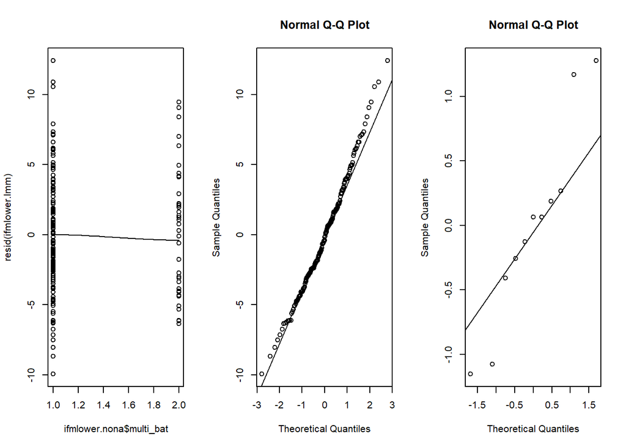

```r
ifmlower.nona <- d_tordered[!is.na(d_tordered$ifm_terminal_frequency),]
ifmlower.formula <- formula(ifm_terminal_frequency~multi_bat+(1|rechour))
ifmlower.lmm <- lmer(ifmlower.formula, data=ifmlower.nona)
# perform residual inspecition
par(mfrow=c(1,3))
scatter.smooth(ifmlower.nona$multi_bat,resid(ifmlower.lmm)) # the residuals seem to show no pattern between the explanatory variables
qqnorm(resid(ifmlower.lmm));qqline(resid(ifmlower.lmm))
qqnorm(ranef(ifmlower.lmm)$rechour$`(Intercept)`);qqline(ranef(ifmlower.lmm)$rechour$`(Intercept)`,main='random effects')
```

The model assumptions are met okay-ish. Now let’s proceed.

```r
ifmlower.sim <- sim(ifmlower.lmm, n.sim=num_post)
ifmlower.fixefs.hpd <- round(apply(fixef(ifmlower.sim),2,get.hpd),2)
ifmlower.fixefs.mean <- round(apply(fixef(ifmlower.sim),2,mean),2)

# rel change

ifmlower.rel.increase <- (fixef(ifmlower.sim)[,1]+fixef(ifmlower.sim)[,2])/fixef(ifmlower.sim)[,1]
ifmlower.rel.hpd <- round(get.hpd(ifmlower.rel.increase), 2)
ifmlower.rel.map <- round(mean(ifmlower.rel.increase), 2)
ifmlower.rel.map.compint <- c(ifmlower.rel.map, ifmlower.rel.hpd)

# change in khz
ifmlower.khz.increase <- fixef(ifmlower.sim)[,2]
ifmlower.khz.hpd <- round(get.hpd(ifmlower.khz.increase), 2)
ifmlower.khz.map <- round(mean(ifmlower.khz.increase), 2)
ifmlower.khz.map.compint <- c(ifmlower.khz.map, ifmlower.khz.hpd)



#Single and Multi bat mean MAP and Compatibility Intervals
ifmlower.single <- fixef(ifmlower.sim)[,1]
ifmlower.multi <- ifmlower.single + fixef(ifmlower.sim)[,2]

# the columns are ordered so: single-mean-MAP, single-mean-lowerCoI, single-mean-upperCoI, multi-mean-lowerCoI, multi-mean-upperCoI
ifmlower.mean.mapcoi <- c(get.map.coi(ifmlower.single), get.map.coi(ifmlower.multi))
```

## CF peak frequency

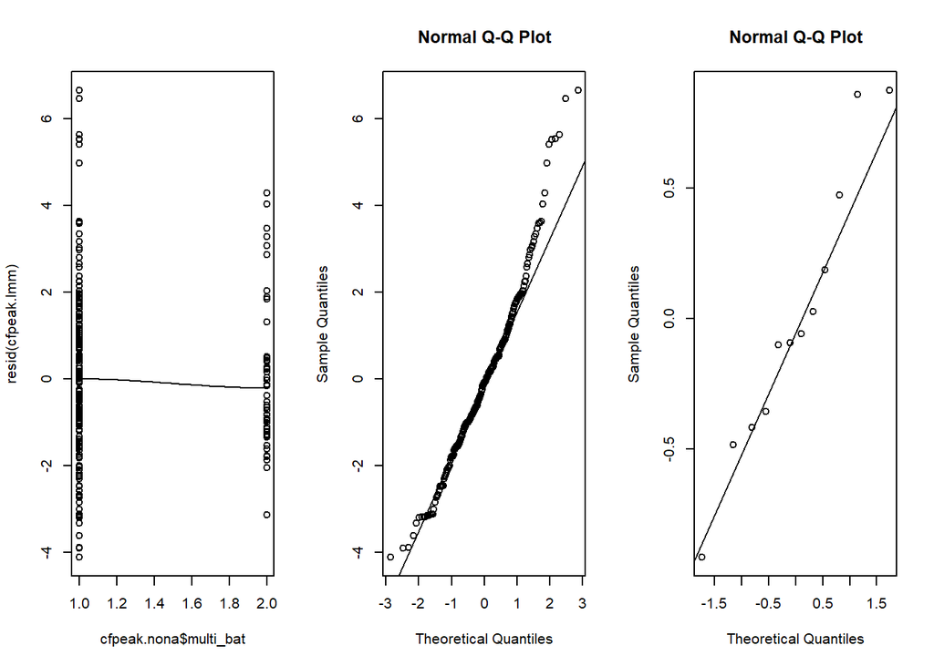

```r
cfpeak.nona <- d_tordered[!is.na(d_tordered$cf_peak_frequency),]
cfpeak.formula <- formula(cf_peak_frequency~multi_bat+(1|rechour))
cfpeak.lmm <- lmer(cfpeak.formula, data=cfpeak.nona)
# perform residual inspecition
par(mfrow=c(1,3))
scatter.smooth(cfpeak.nona$multi_bat,resid(cfpeak.lmm)) # the residuals seem to show no pattern between the explanatory variables
qqnorm(resid(cfpeak.lmm));qqline(resid(cfpeak.lmm))
qqnorm(ranef(cfpeak.lmm)$rechour$`(Intercept)`);qqline(ranef(cfpeak.lmm)$rechour$`(Intercept)`,main='random effects')
```

The model assumptions are met okay’ish. Now let’s proceed.

```r
cfpeak.sim <- sim(cfpeak.lmm, n.sim=num_post)

cfpeak.fixefs.hpd <- round(apply(fixef(cfpeak.sim),2,get.hpd),2)
cfpeak.fixefs.mean <- round(apply(fixef(cfpeak.sim),2,mean),2)

# rel increase
cfpeak.rel.increase <- (fixef(cfpeak.sim)[,1]+fixef(cfpeak.sim)[,2])/fixef(cfpeak.sim)[,1]
cfpeak.rel.hpd <- round(get.hpd(cfpeak.rel.increase),3)
cfpeak.rel.map <- round(mean(cfpeak.rel.increase), 3)
cfpeak.rel.map.compint <- c(cfpeak.rel.map, cfpeak.rel.hpd)

# change khz
cfpeak.increase <- fixef(cfpeak.sim)[,2]
cfpeak.khz.hpd <- round(get.hpd(cfpeak.increase), 2)
cfpeak.khz.map <- round(mean(cfpeak.increase), 2)
cfpeak.khz.map.compint <- c(cfpeak.khz.map, cfpeak.khz.hpd)




#Single and Multi bat mean MAP and Compatibility Intervals
cfpeak.single <- fixef(cfpeak.sim)[,1]
cfpeak.multi <- cfpeak.single + fixef(cfpeak.sim)[,2]

# the columns are ordered so: single-mean-MAP, single-mean-lowerCoI, single-mean-upperCoI, multi-mean-lowerCoI, multi-mean-upperCoI
cfpeak.mean.mapcoi <- c(get.map.coi(cfpeak.single), get.map.coi(cfpeak.multi))
```

The mean CF peak frequency in single bats is 105.55kHz, and multi-bat calls show an average difference of 0.4kHz. The relative increase of multi-bat CF peak frequency is in the range of 0.998, 1.01, in comparison to single bat calls.

## tFM received level

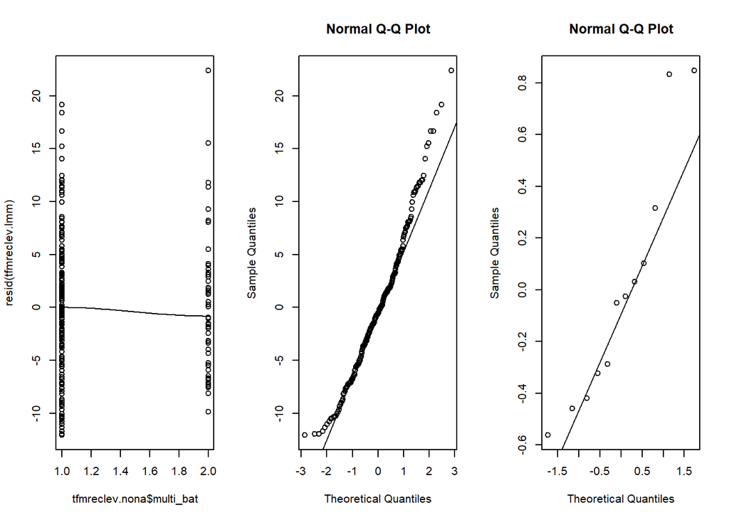

```r
tfmreclev.nona <- d_tordered[!is.na(d_tordered$tfm_dbrms),]
tfmreclev.formula <- formula(tfm_dbrms~multi_bat+(1|rechour))
tfmreclev.lmm <- lmer(tfmreclev.formula, data=tfmreclev.nona)
# perform residual inspecition
par(mfrow=c(1,3))
scatter.smooth(tfmreclev.nona$multi_bat,resid(tfmreclev.lmm)) # the residuals seem to show no pattern between the explanatory variables
qqnorm(resid(tfmreclev.lmm));qqline(resid(tfmreclev.lmm))
qqnorm(ranef(tfmreclev.lmm)$rechour$`(Intercept)`);qqline(ranef(tfmreclev.lmm)$rechour$`(Intercept)`)
```

The fit seems okay, now let’s proceed to the posterior of the coefficients.

```r
tfmreclev.sim <- sim(tfmreclev.lmm, n.sim=num_post)

tfmreclev.fixefs.hpd <- round(apply(fixef(tfmreclev.sim),2,get.hpd),2)
tfmreclev.fixefs.mean <- round(apply(fixef(tfmreclev.sim),2,mean),2)

# increase in dB  -- CALCULATING RATIOS OF DB'S doesn't make sense
tfmreclev.db.increase <-  fixef(tfmreclev.sim)[,2]
tfmreclev.db.hpd <- round(get.hpd(tfmreclev.db.increase),2)
tfmreclev.db.map <- round(mean(tfmreclev.db.increase), 2)
tfmreclev.db.map.compint <- c(tfmreclev.db.map, tfmreclev.db.hpd)



#Single and Multi bat mean MAP and Compatibility Intervals
tfmreclev.single <- fixef(tfmreclev.sim)[,1]
tfmreclev.multi <- tfmreclev.single + fixef(tfmreclev.sim)[,2]

# the columns are ordered so: single-mean-MAP, single-mean-lowerCoI, single-mean-upperCoI, multi-mean-lowerCoI, multi-mean-upperCoI
tfmreclev.mean.mapcoi <- c(get.map.coi(tfmreclev.single), get.map.coi(tfmreclev.multi))
```

## iFM received level

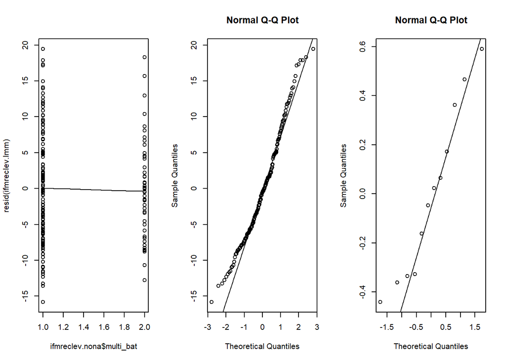

```r
ifmreclev.nona <- d_tordered[!is.na(d_tordered$ifm_dbrms),]
ifmreclev.formula <- formula(ifm_dbrms~multi_bat+(1|rechour))
ifmreclev.lmm <- lmer(ifmreclev.formula, data=ifmreclev.nona)
# perform residual inspecition
par(mfrow=c(1,3))
scatter.smooth(ifmreclev.nona$multi_bat,resid(ifmreclev.lmm))
qqnorm(resid(ifmreclev.lmm));qqline(resid(ifmreclev.lmm))
qqnorm(ranef(ifmreclev.lmm)$rechour$`(Intercept)`);qqline(ranef(ifmreclev.lmm)$rechour$`(Intercept)`,main='random effects')
```

The residual fit is not too bad. Now off to estimating the parameter posteriors.

```r
ifmreclev.sim <- sim(ifmreclev.lmm, n.sim=num_post)

ifmreclev.fixefs.hpd <- round(apply(fixef(ifmreclev.sim),2,get.hpd),2)
ifmreclev.fixefs.mean <- round(apply(fixef(ifmreclev.sim),2,mean),2)

# only calculate dB increase -- and not ratios of dB's!!!
ifmreclev.db.increase <- fixef(ifmreclev.sim)[,2]
ifmreclev.db.hpd <- round(get.hpd(ifmreclev.db.increase),2)
ifmreclev.db.map <- round(mean(ifmreclev.db.increase), 2)
ifmreclev.db.map.compint <- c(ifmreclev.db.map, ifmreclev.db.hpd)


#Single and Multi bat mean MAP and Compatibility Intervals
ifmreclev.single <- fixef(ifmreclev.sim)[,1]
ifmreclev.multi <- ifmreclev.single + fixef(ifmreclev.sim)[,2]

# the columns are ordered so: single-mean-MAP, single-mean-lowerCoI, single-mean-upperCoI, multi-mean-lowerCoI, multi-mean-upperCoI
ifmreclev.mean.mapcoi <- c(get.map.coi(ifmreclev.single), get.map.coi(ifmreclev.multi))
```

## CF received level

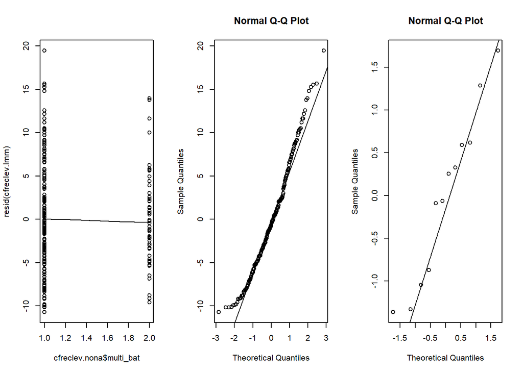

```r
cfreclev.nona <- d_tordered[!is.na(d_tordered$cf_dbrms),]
cfreclev.formula <- formula(cf_dbrms~multi_bat+(1|rechour))
cfreclev.lmm <- lmer(cfreclev.formula, data=cfreclev.nona)
# perform residual inspecition
par(mfrow=c(1,3))
scatter.smooth(cfreclev.nona$multi_bat,resid(cfreclev.lmm))
qqnorm(resid(cfreclev.lmm));qqline(resid(cfreclev.lmm))
qqnorm(ranef(cfreclev.lmm)$rechour$`(Intercept)`);qqline(ranef(cfreclev.lmm)$rechour$`(Intercept)`)
```

```r
cfreclev.sim <- sim(cfreclev.lmm, n.sim=num_post)

cfreclev.fixefs.hpd <- round(apply(fixef(cfreclev.sim),2,get.hpd),2)
cfreclev.fixefs.mean <- round(apply(fixef(cfreclev.sim),2,mean),2)

# dB ratios -- only difference!

cfreclev.db.increase <- fixef(cfreclev.sim)[,2]
cfreclev.db.hpd <- round(get.hpd(cfreclev.db.increase),2)
cfreclev.db.map <- round(mean(cfreclev.db.increase), 2)
cfreclev.db.map.compint <- c(cfreclev.db.map, cfreclev.db.hpd)



#Single and Multi bat mean MAP and Compatibility Intervals
cfreclev.single <- fixef(cfreclev.sim)[,1]
cfreclev.multi <- cfreclev.single + fixef(cfreclev.sim)[,2]

# the columns are ordered so: single-mean-MAP, single-mean-lowerCoI, single-mean-upperCoI, multi-mean-lowerCoI, multi-mean-upperCoI
cfreclev.mean.mapcoi <- c(get.map.coi(cfreclev.single), get.map.coi(cfreclev.multi))
```

## tFM-CF level ratio

```r
d_tordered$tfm_cf <- d_tordered$tfm_dbrms-d_tordered$cf_dbrms
tfmcf.nona <- d_tordered[!is.na(d_tordered$tfm_cf),]
tfmcfreclev.nona <- d_tordered[!is.na(d_tordered$tfm_cf),]
tfmcfreclev.formula <- formula(tfm_cf~multi_bat+(1|rechour))
tfmcfreclev.lmm <- lmer(tfmcfreclev.formula, data=tfmcfreclev.nona)
```

```
## boundary (singular) fit: see help('isSingular')
```

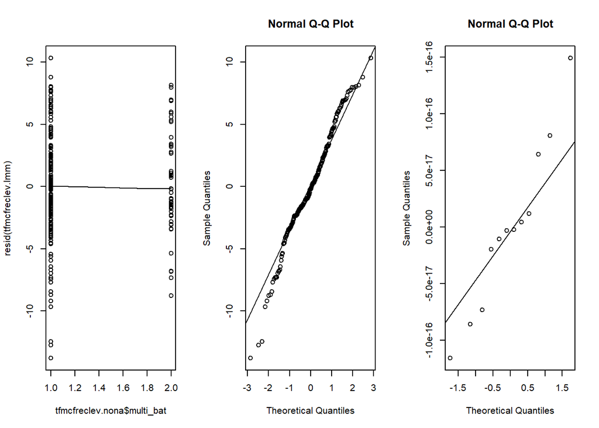

```r
# perform residual inspecition
par(mfrow=c(1,3))
scatter.smooth(tfmcfreclev.nona$multi_bat,resid(tfmcfreclev.lmm))
qqnorm(resid(tfmcfreclev.lmm));qqline(resid(tfmcfreclev.lmm))
qqnorm(ranef(tfmcfreclev.lmm)$rechour$`(Intercept)`);qqline(ranef(tfmcfreclev.lmm)$rechour$`(Intercept)`,main='random effects')
```

```r
tfmcfreclev.sim <- sim(tfmcfreclev.lmm, n.sim=num_post)

# dB difference only
tfmcfreclev.fixefs.hpd <- round(apply(fixef(tfmcfreclev.sim),2,get.hpd),2)
tfmcfreclev.fixefs.mean <- round(apply(fixef(tfmcfreclev.sim),2,mean),2)
tfmcfreclev.db <- (fixef(tfmcfreclev.sim)[,1]+fixef(tfmcfreclev.sim)[,2]) - fixef(tfmcfreclev.sim)[,1]
tfmcfreclev.db.hpd <- round(get.hpd(tfmcfreclev.db),2)
tfmcfreclev.db.map <- round(mean(tfmcfreclev.db), 2)
tfmcfreclev.db.map.compint <- c(tfmcfreclev.db.map, tfmcfreclev.db.hpd)



#Single and Multi bat mean MAP and Compatibility Intervals
tfmcfreclev.single <- fixef(tfmcfreclev.sim)[,1]
tfmcfreclev.multi <- tfmcfreclev.single + fixef(tfmcfreclev.sim)[,2]

# the columns are ordered so: single-mean-MAP, single-mean-lowerCoI, single-mean-upperCoI, multi-mean-lowerCoI, multi-mean-upperCoI
tfmcfreclev.mean.mapcoi <- c(get.map.coi(tfmcfreclev.single), get.map.coi(tfmcfreclev.multi))
```

## iFM-CF level ratio

```r
d_tordered$ifm_cf <- d_tordered$ifm_dbrms-d_tordered$cf_dbrms
ifmcf.nona <- d_tordered[!is.na(d_tordered$ifm_cf),]
ifmcfreclev.nona <- d_tordered[!is.na(d_tordered$ifm_cf),]
ifmcfreclev.formula <- formula(ifm_cf~multi_bat+(1|rechour))
ifmcfreclev.lmm <- lmer(ifmcfreclev.formula, data=ifmcfreclev.nona)
```

```
## boundary (singular) fit: see help('isSingular')
```

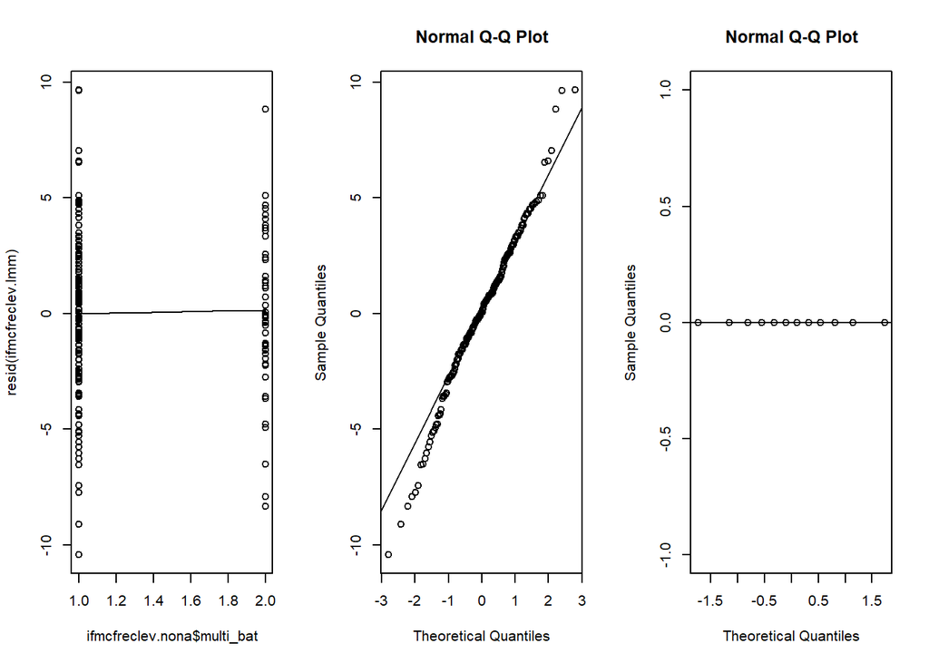

```r
# perform residual inspecition
par(mfrow=c(1,3))
scatter.smooth(ifmcfreclev.nona$multi_bat,resid(ifmcfreclev.lmm))
qqnorm(resid(ifmcfreclev.lmm));qqline(resid(ifmcfreclev.lmm))
qqnorm(ranef(ifmcfreclev.lmm)$rechour$`(Intercept)`);qqline(ranef(ifmcfreclev.lmm)$rechour$`(Intercept)`,main='random effects')
```

```r
ifmcfreclev.sim <- sim(ifmcfreclev.lmm, n.sim=num_post)

ifmcfreclev.fixefs.hpd <- round(apply(fixef(ifmcfreclev.sim),2,get.hpd),2)
ifmcfreclev.fixefs.mean <- round(apply(fixef(ifmcfreclev.sim),2,mean),2)

# only db difference
ifmcfreclev.db.increase <- fixef(ifmcfreclev.sim)[,2]
ifmcfreclev.db.hpd <- round(get.hpd(ifmcfreclev.db.increase),2)
ifmcfreclev.db.map <- round(mean(ifmcfreclev.db.increase), 2)
ifmcfreclev.db.map.compint <- c(ifmcfreclev.db.map, ifmcfreclev.db.hpd)



#Single and Multi bat mean MAP and Compatibility Intervals
ifmcfreclev.single <- fixef(ifmcfreclev.sim)[,1]
ifmcfreclev.multi <- ifmcfreclev.single + fixef(ifmcfreclev.sim)[,2]

# the columns are ordered so: single-mean-MAP, single-mean-lowerCoI, single-mean-upperCoI, multi-mean-lowerCoI, multi-mean-upperCoI
ifmcfreclev.mean.mapcoi <- c(get.map.coi(ifmcfreclev.single), get.map.coi(ifmcfreclev.multi))
```

## tFM bandwidth

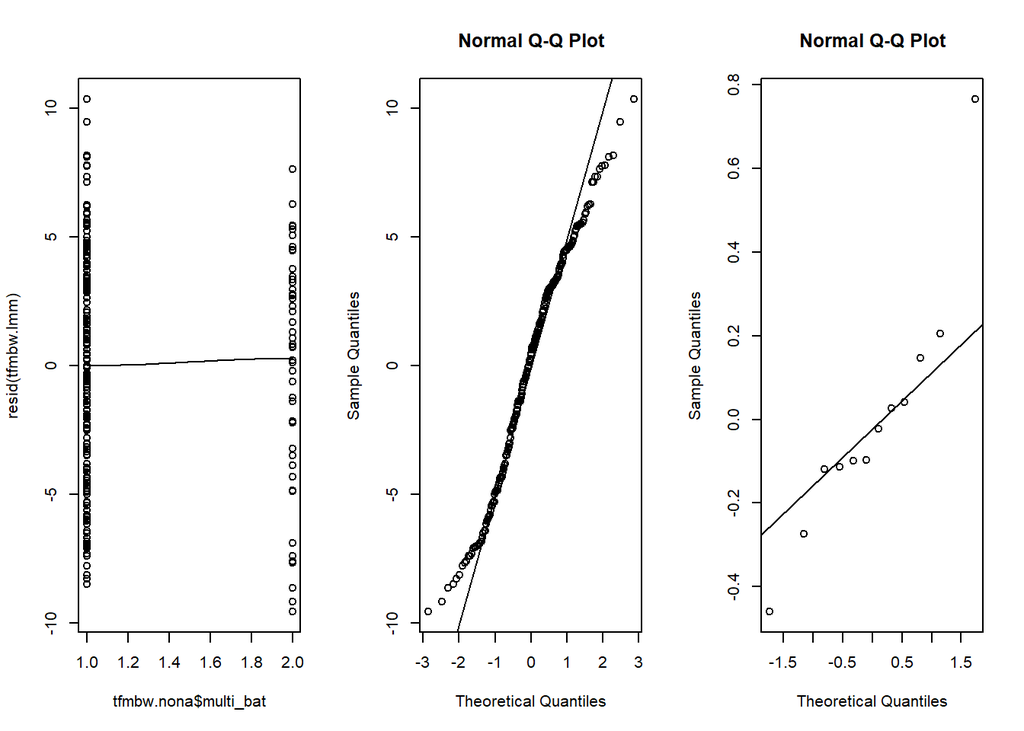

```r
d_tordered$tfm_bw <- d_tordered$cf_peak_frequency-d_tordered$tfm_terminal_frequency
tfmbw.nona <- d_tordered[!is.na(d_tordered$tfm_bw),]
tfmbw.formula <- formula(tfm_bw~multi_bat+(1|rechour))
tfmbw.lmm <- lmer(tfmbw.formula, data=tfmbw.nona)
# perform residual inspecition
par(mfrow=c(1,3))
scatter.smooth(tfmbw.nona$multi_bat,resid(tfmbw.lmm))
qqnorm(resid(tfmbw.lmm));qqline(resid(tfmbw.lmm))
qqnorm(ranef(tfmbw.lmm)$rechour$`(Intercept)`);qqline(ranef(tfmbw.lmm)$rechour$`(Intercept)`,main='random effects')
```

```r
tfmbw.sim <- sim(tfmbw.lmm, n.sim=num_post)

tfmbw.fixefs.hpd <- round(apply(fixef(tfmbw.sim),2,get.hpd),2)
tfmbw.fixefs.mean <- round(apply(fixef(tfmbw.sim),2,mean),2)

# relative increase
tfmbw.rel.increase <- (fixef(tfmbw.sim)[,1]+fixef(tfmbw.sim)[,2])/fixef(tfmbw.sim)[,1]
tfmbw.rel.hpd <- round(get.hpd(tfmbw.rel.increase),2)
tfmbw.rel.map <- round(mean(tfmbw.rel.increase), 2)
tfmbw.rel.map.compint <- c(tfmbw.rel.map, tfmbw.rel.hpd)

# increse khz
tfmbw.khz.increase <- fixef(tfmbw.sim)[,2]
tfmbw.khz.hpd <- round(get.hpd(tfmbw.khz.increase), 2)
tfmbw.khz.map <- round(mean(tfmbw.khz.increase), 2)
tfbw.khz.map.compint <- c(tfmbw.khz.map, tfmbw.khz.hpd)




#Single and Multi bat mean MAP and Compatibility Intervals
tfmbw.single <- fixef(tfmbw.sim)[,1]
tfmbw.multi <- tfmbw.single + fixef(tfmbw.sim)[,2]

# the columns are ordered so: single-mean-MAP, single-mean-lowerCoI, single-mean-upperCoI, multi-mean-lowerCoI, multi-mean-upperCoI
tfmbw.mean.mapcoi <- c(get.map.coi(tfmbw.single), get.map.coi(tfmbw.multi))
```

## iFM bandwidth

```r
d_tordered$ifm_bw <- d_tordered$cf_peak_frequency-d_tordered$ifm_terminal_frequency
ifmbw.nona <- d_tordered[!is.na(d_tordered$ifm_bw),]
ifmbw.formula <- formula(ifm_bw~multi_bat+(1|rechour))
ifmbw.lmm <- lmer(ifmbw.formula, data=ifmbw.nona)
```

```
## boundary (singular) fit: see help('isSingular')
```

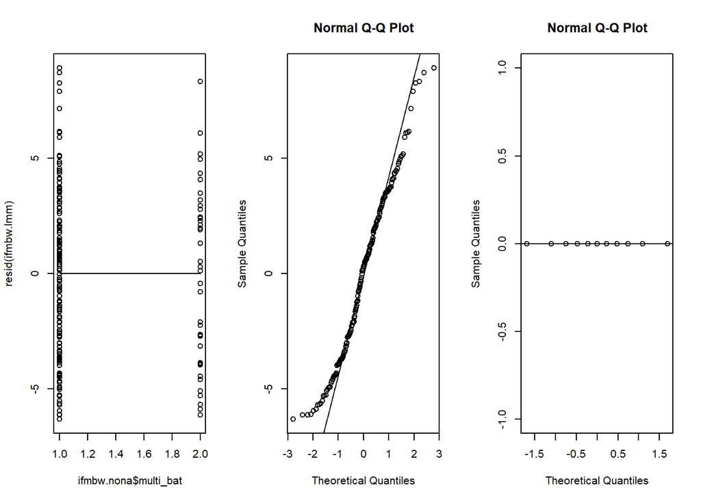

```r
# perform residual inspecition
par(mfrow=c(1,3))
scatter.smooth(ifmbw.nona$multi_bat,resid(ifmbw.lmm))
qqnorm(resid(ifmbw.lmm));qqline(resid(ifmbw.lmm))
qqnorm(ranef(ifmbw.lmm)$rechour$`(Intercept)`);qqline(ranef(ifmbw.lmm)$rechour$`(Intercept)`,main='random effects')
```

```r
ifmbw.sim <- sim(ifmbw.lmm, n.sim=num_post)

ifmbw.fixefs.hpd <- round(apply(fixef(ifmbw.sim),2,get.hpd),2)
ifmbw.fixefs.mean <- round(apply(fixef(ifmbw.sim),2,mean),2)

# relative change
ifmbw.rel.increase <- (fixef(ifmbw.sim)[,1]+fixef(ifmbw.sim)[,2])/fixef(ifmbw.sim)[,1]
ifmbw.rel.hpd <- round(get.hpd(ifmbw.rel.increase), 2)
ifmbw.rel.map <- round(mean(ifmbw.rel.increase), 2)
ifmbw.rel.map.compint <- c(ifmbw.rel.map, ifmbw.rel.hpd)

# khz change
ifmbw.khz.change <- fixef(ifmbw.sim)[,2]
ifmbw.khz.hpd <- round(get.hpd(ifmbw.khz.change) ,2)
ifmbw.khz.map <- round(mean(ifmbw.khz.change), 2)
ifmbw.khz.map.compint <- c(ifmbw.khz.map, ifmbw.khz.hpd)



#Single and Multi bat mean MAP and Compatibility Intervals
ifmbw.single <- fixef(ifmbw.sim)[,1]
ifmbw.multi <- ifmbw.single + fixef(ifmbw.sim)[,2]

# the columns are ordered so: single-mean-MAP, single-mean-lowerCoI, single-mean-upperCoI, multi-mean-lowerCoI, multi-mean-upperCoI
ifmbw.mean.mapcoi <- c(get.map.coi(ifmbw.single), get.map.coi(ifmbw.multi))
```

## Summary of all parameters

```r
# renaming the output variables because they're so long...
cfdurn.diff.mcoi <- cfdurn.diff.map.compint; cfdurn.rel.mcoi <- cfdurn.rel.map.compint
tfmdurn.diff.mcoi <- tfmdurn.ms.change.map.compint ; tfmdurn.rel.mcoi <- tfmdurn.rel.map.compint
ifmdurn.diff.mcoi <- ifmdurn.ms.change.map.compint; ifmdurn.rel.mcoi <- ifmdurn.rel.map.compint
# frequency stuff
cfpeak.diff.mcoi <- cfpeak.khz.map.compint ; cfpeak.rel.mcoi <- cfpeak.rel.map.compint
tfmlower.diff.mcoi <- tfmlower.khz.map.compint; tfmlower.rel.mcoi <- tfmlower.rel.map.compint
ifmlower.diff.mcoi <- ifmlower.khz.map.compint; ifmlower.rel.mcoi <- ifmlower.rel.map.compint
# received level
cfreclev.mcoi <- cfreclev.db.map.compint
tfmreclev.mcoi <- tfmreclev.db.map.compint
ifmreclev.mcoi <- ifmreclev.db.map.compint
# ratios
tfmcf.diff.mcoi <- tfmcfreclev.db.map.compint
ifmcf.diff.mcoi <- ifmcfreclev.db.map.compint
# bandwidths
tfmbw.diff.mcoi <- tfbw.khz.map.compint ; tfmbw.rel.mcoi <- tfmbw.rel.map.compint
ifmbw.diff.mcoi <- ifmbw.khz.map.compint ; ifmbw.rel.mcoi <- ifmbw.rel.map.compint
```

Derived estimates of mean differences between multi and single bat calls, and relative change of multi-bat calls with respect to single bat calls. The relative change has not been calculated for received levels and relative received levels as the dB scale already represents a relative measurement.

[output not shown]

```r
# save the same table above as a csv file  with additional columns
component <- c(rep(c('CF','tFM','iFM'),3),'tFM-CF','iFM-CF','tFM','iFM')
parameter <- c(rep('Duration, ms',3), 'Peak frequency, kHz',
                rep('Lower frequency, kHz',2), rep('Amplitude, dB rms',3),
                'Level difference, dB', 'Level difference, dB', rep('Bandwidth, kHz',2))

# The Multi-Single difference and 95% HPD limits
diff.map.coi <- rbind(cfdurn.diff.mcoi,            tfmdurn.diff.mcoi,     ifmdurn.diff.mcoi,
                  cfpeak.diff.mcoi,      tfmlower.diff.mcoi,    ifmlower.diff.mcoi,
                  cfreclev.mcoi,    tfmreclev.mcoi,   ifmreclev.mcoi,
                  tfmcf.diff.mcoi, ifmcf.diff.mcoi,
                  tfmbw.diff.mcoi,ifmbw.diff.mcoi)

# The Multi/Single relative ratio and 95% HPD limits
rel.map.coi <- rbind(cfdurn.rel.mcoi, tfmdurn.rel.mcoi, ifmdurn.rel.mcoi,
                     cfpeak.rel.mcoi, tfmlower.rel.mcoi, ifmlower.rel.mcoi,
                     rep(NA, 3), rep(NA, 3), rep(NA, 3),
                    rep(NA, 3),  rep(NA, 3),
                    tfmbw.rel.mcoi, ifmbw.rel.mcoi)


all.ind.summary <- data.frame(cbind(component, parameter, diff.map.coi, rel.map.coi))
row.names(all.ind.summary) <- NULL
colnames(all.ind.summary) <- c('Component', 'Parameter', 'Difference-MAP', 'diff_lower_95pcHPD','diff_upper_95pcHPD', 'Ratio-MAP', 'ratio_lower_95pcHPD', 'ratio_upper_95pcHPD')
write.csv(all.ind.summary,'all_ind_summary.csv')

# irrelevant one-liner lapply(all.ind.summary$diff_lower_95pcHPD, function(x) format(as.numeric(x), nsmall=2))
```

## Mean and compatibility Intervals

```r
all_mean_mapcoi <-  data.frame(rbind(cfdurn.mean.mapcoi, tfmdurn.mean.mapcoi, ifmdurn.mean.mapcoi,
                          cfpeak.mean.mapcoi, tfmlower.mean.mapcoi, ifmlower.mean.mapcoi,
                          cfreclev.mean.mapcoi, tfmreclev.mean.mapcoi, ifmreclev.mean.mapcoi,
                          tfmcfreclev.mean.mapcoi, ifmcfreclev.mean.mapcoi,
                          tfmbw.mean.mapcoi, ifmbw.mean.mapcoi))
colnames(all_mean_mapcoi) <- c('single-map', 'single-95hpd-lo','single-95hpd-hi','multi-map','multi-95hpd-lo','multi-95hpd-hi')
write.csv(all_mean_mapcoi, 'single-multi_estimatedmeans.csv')
```

## References

Gelman, Andrew, and Sander Greenland. 2019. “Are Confidence Intervals Better Termed ‘Uncertainty Intervals’?” *BMJ* 366.

McElreath, Richard. 2020. *Statistical Rethinking: A Bayesian Course with Examples in r and Stan*. CRC press.

Nalborczyk, Ladislas, Paul-Christian Bürkner, Donald R Williams, and Victoria Savalei. 2019. “Pragmatism Should Not Be a Substitute for Statistical Literacy, a Commentary on Albers, Kiers, and van Ravenzwaaij (2018).” *Collabra: Psychology* 5 (1).